# Unrelated Questions, But Interesting

Clears the local variables and imports the data

```r
rm(list = ls())
library(ggplot2)
library(glmmTMB)
library(MASS)
dat = read.table("Data/exam2022_part2-1.txt", header = T)
dat$horndif <- dat$hornR - dat$hornL
dat$agegroup <- floor(dat$age/3)
```

## Horn Asymmetry vs. Age (by Sex)

Plots horn asymmetry vs age, coloured according to sex.

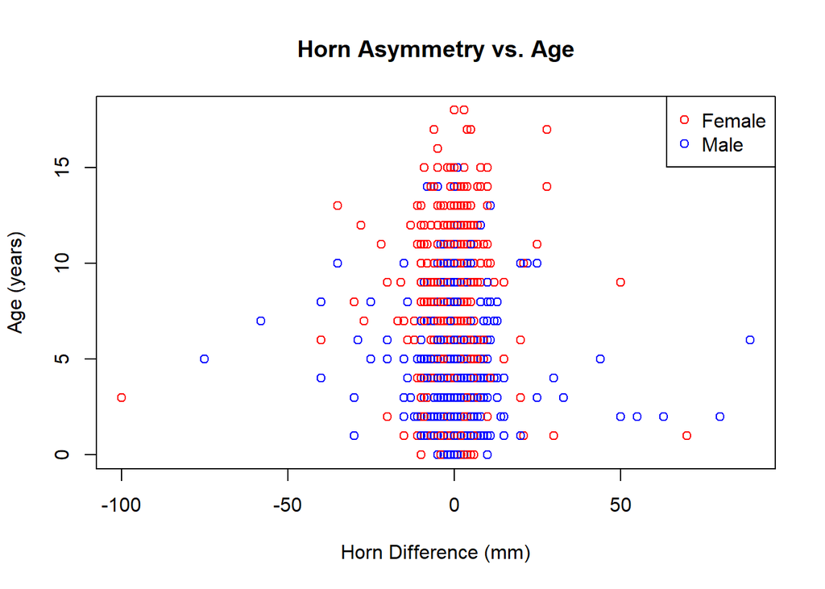

```r
plot(dat$horndif, dat$age,
     col = c("red", "blue")[(dat$sex == "M") + 1],
     main = "Horn Asymmetry vs. Age",
     xlab = "Horn Difference (mm)", ylab = "Age (years)")
legend("topright", c("Female", "Male"), pch = 1, col = c("red", "blue"))
```

```r
summary(lm(dat$horndif ~ dat$age))
```

```
##
## Call:
## lm(formula = dat$horndif ~ dat$age)
##
## Residuals:
##      Min       1Q   Median       3Q      Max
## -100.204   -1.844   -0.152    1.796   88.950
##
## Coefficients:
##             Estimate Std. Error t value Pr(>|t|)
## (Intercept)  0.35789    0.14053   2.547   0.0109 *
## dat$age     -0.05138    0.02693  -1.908   0.0564 .
## ---
## Signif. codes:  0 '***' 0.001 '**' 0.01 '*' 0.05 '.' 0.1 ' ' 1
##
## Residual standard error: 5.694 on 4392 degrees of freedom
## Multiple R-squared:  0.0008283,  Adjusted R-squared:  0.0006008
## F-statistic: 3.641 on 1 and 4392 DF,  p-value: 0.05644
```

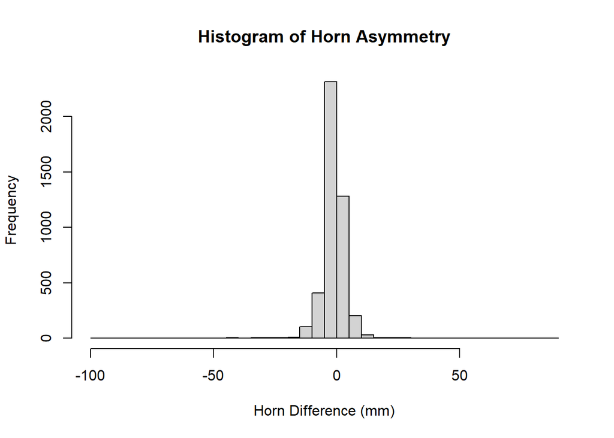

```r
hist(dat$horndif, breaks = 30, xlab = "Horn Difference (mm)", ylab = "Frequency",
    main = "Histogram of Horn Asymmetry")
```

```r
summary(dat$horndif)
```

```
##      Min.   1st Qu.    Median      Mean   3rd Qu.      Max.
## -100.0000   -2.0000    0.0000    0.1457    2.0000   89.0000
```

```r
# ggplot(dat, aes((hornR - hornL), age)) +
#     geom_violin() +
#     geom_vline(xintercept = 0) +
#     geom_point(aes(colour = sex)) +
#     scale_colour_manual(values = (c(F = "violetred", M = "navy"))) +
#     labs(x = "Difference in Horn Lengths (mm)",
#          y = "Age (years)",
#          title = "Horn Asymmetry by Age")
```

## Body Mass Over Time (by Sex)

Plots body mass (kg) over time.

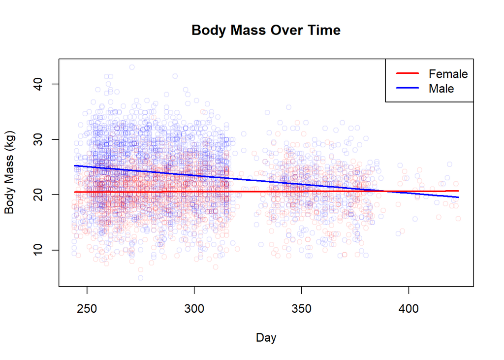

```r
plot(dat$daynr, dat$mass,
     col = c(rgb(1, 0, 0, 0.1), rgb(0, 0, 1, 0.1))[(dat$sex == "M") + 1],
     main = "Body Mass Over Time", xlab = "Day", ylab = "Body Mass (kg)")
legend("topright", c("Female", "Male"),
       lty = 1, lwd = 2, col = c("red", "blue"))

xp <- min(dat$daynr):max(dat$daynr)
m2 <- lm(dat$mass[dat$sex == "M"] ~ dat$daynr[dat$sex == "M"])
m3 <- lm(dat$mass[dat$sex == "F"] ~ dat$daynr[dat$sex == "F"])
lines(xp, m2$coef[1] + m2$coef[2]*xp, col = "blue", lwd = 2)
lines(xp, m3$coef[1] + m3$coef[2]*xp, col = "red", lwd = 2)
```

```r
# A violin plot which, while cool, doesn't accurately represent what I thought it represented originally
# ggplot(dat, aes(daynr, mass, colour = sex)) +
#     scale_colour_manual(values = c(F = rgb(1, 0, 0, 0.1), M = rgb(0, 0, 1, 0.1))) +
#     geom_point() +
#     geom_smooth(formula = y ~ x, method = "lm")
```

Plots the histograms of the residuals. They appear to be approximately normal but slightly left-skewed.

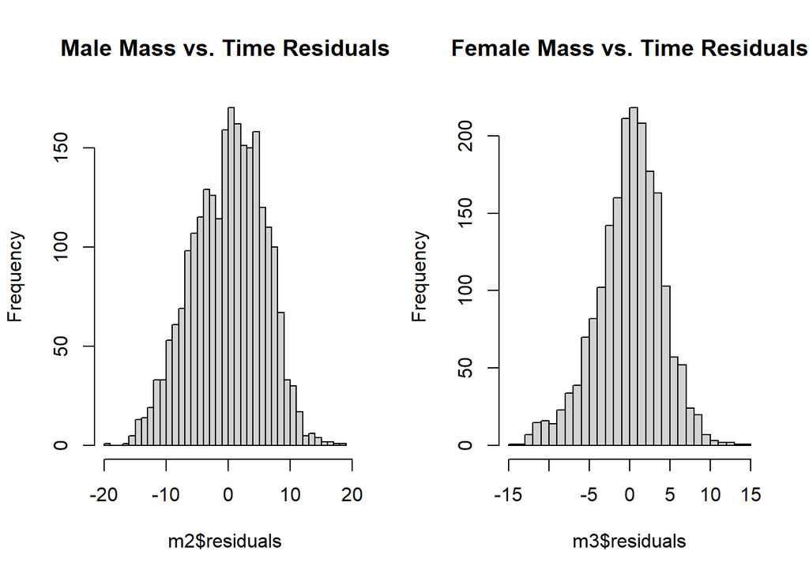

```r
op <- par(mfrow = c(1, 2))
hist(m2$residuals, breaks = 30, main = "Male Mass vs. Time Residuals")
hist(m3$residuals, breaks = 30, main = "Female Mass vs. Time Residuals")
```

```r
par(op)
```

## Total Hunted Each Year (by Sex)

Creates a barplot of hunting over all years.

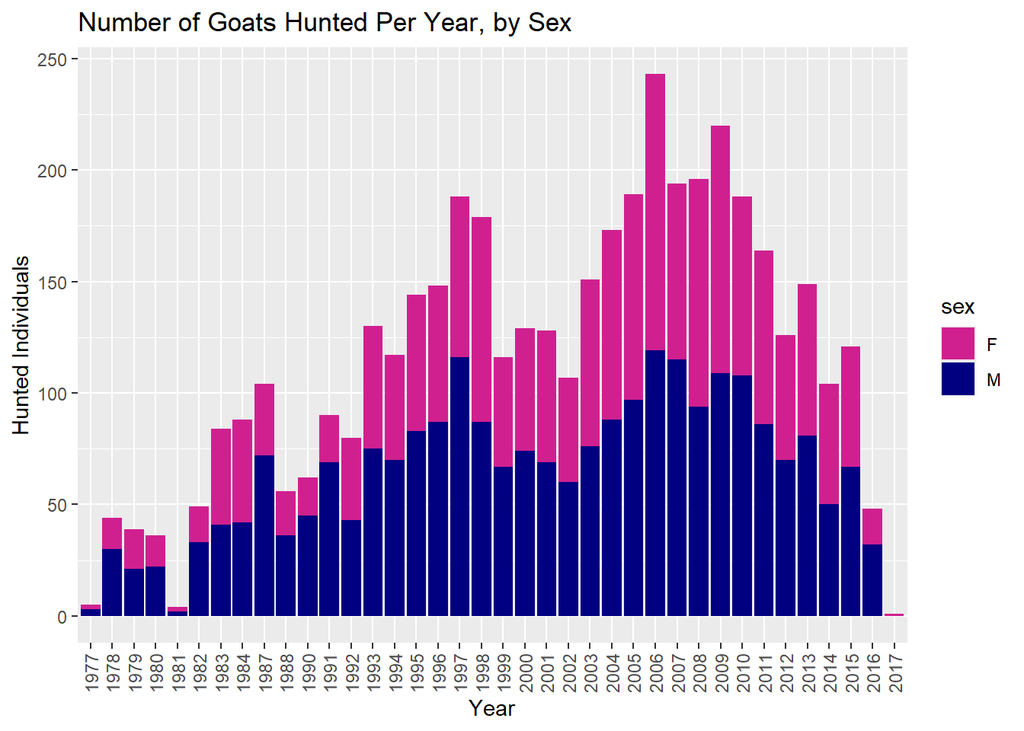

```r
ggplot(dat, aes(as.factor(yr), fill = sex)) +
    geom_bar(position = "stack") +
    theme(axis.text.x = element_text(angle = 90, vjust = 0.5, hjust = 1)) +
    scale_fill_manual(values = c(F = "violetred", M = "navy")) +
    labs(x = "Year", y = "Hunted Individuals", title = "Number of Goats Hunted Per Year, by Sex")
```

# Hunted Horn Length Over Time

## Simple Plot

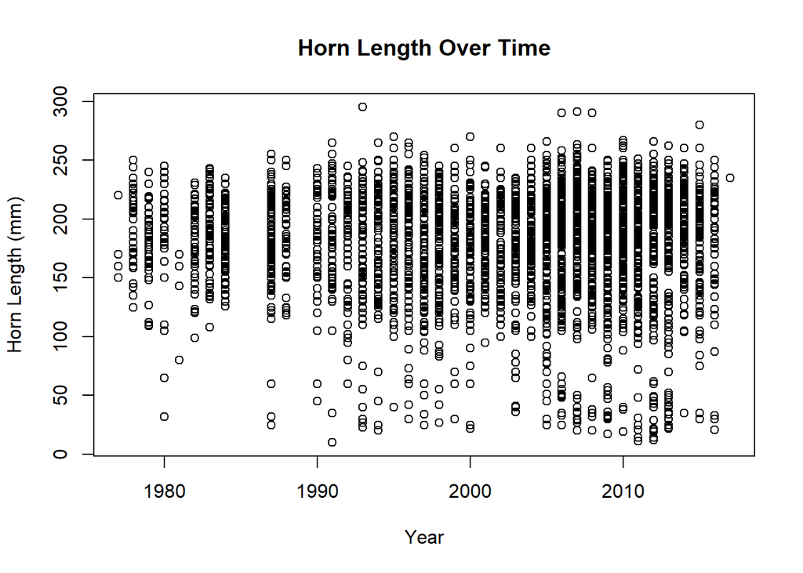

```r
plot(dat$yr, dat$hornL, main = "Horn Length Over Time", xlab = "Year", ylab = "Horn Length (mm)")
```

## Boxplots for Each Year

Creates a chart of boxplots of horn length for every year.

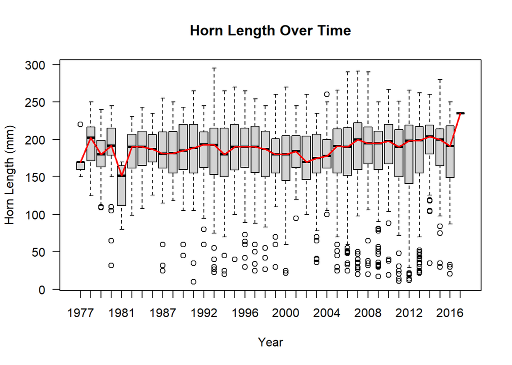

```r
hornmeds <- tapply(dat$hornL, dat$yr, median)  # Horn length median/year
agemeds <- tapply(dat$age, dat$yr, median)  # Age median/year

plot(as.factor(dat$yr), dat$hornL, las = 1,
     xlab = "Year", ylab = "Horn Length (mm)",
     main = "Horn Length Over Time")
lines(as.factor(names(hornmeds)), unname(hornmeds),
      col = "red", lwd = 2)
```

Horn length medians over time, with points scaled according to median age and coloured according to number of data points for that year.

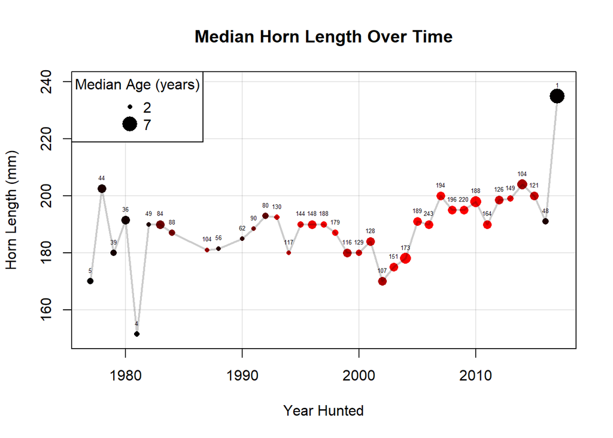

```r
# Creates a colour palette scaling from black to red
gradient <- colorRampPalette(c("black", "red"))(max(unname(table(dat$yr))))

scalef <- 3  # Scale-down factor for ages -> point size

# A function used to make the colouring curve non-linear to my liking (I moved the threshold to start turning red lower than it was originally)
colfunc <- function(x) (max(unname(table(dat$yr)))/(1 + exp(-0.045*(x - 90))))

# Plots years (names of horn medians) against medians (values of horn medians)
plot(as.numeric(names(hornmeds)), unname(hornmeds), pch = 16, cex = agemeds/scalef,
     col = gradient[colfunc(unname(table(dat$yr)))],
     xlab = "Year Hunted", ylab = "Horn Length (mm)",
     main = "Median Horn Length Over Time",
     ylim = c(150, 240))

# Labels the points with the number of data points for that year
text(as.numeric(names(hornmeds)), unname(hornmeds), unname(table(dat$yr)),
     pos = 3, cex = 0.4)

# Draws connecting line
lines(as.numeric(names(hornmeds)), unname(hornmeds), col = rgb(0, 0, 0, 0.2), lwd = 2)

# Adds light grid behind
grid(lty = 1, col = rgb(0, 0, 0, 0.1))

# Legend to show point scaling reflecting median age
legend("topleft", legend = c(min(agemeds), max(agemeds)), pch = 16,
       pt.cex = c(min(agemeds)/scalef, max(agemeds)/scalef),
       title = "Median Age (years)")
```

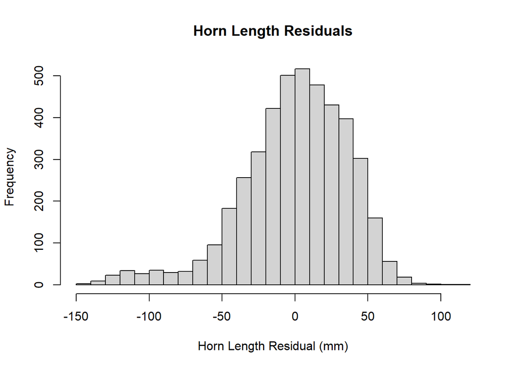

```r
# Linear model and residual histogram
m4 <- lm(hornL ~ yr * age, data = dat)
hist(m4$res, breaks = 20,
     main = "Horn Length Residuals", xlab = "Horn Length Residual (mm)")
```

```r
summary(m4)
```

```
##
## Call:
## lm(formula = hornL ~ yr * age, data = dat)
##
## Residuals:
##      Min       1Q   Median       3Q      Max
## -148.001  -20.262    3.393   26.178  119.139
##
## Coefficients:
##               Estimate Std. Error t value Pr(>|t|)
## (Intercept) 1540.79026  195.64500   7.875 4.25e-15 ***
## yr            -0.69479    0.09777  -7.106 1.39e-12 ***
## age         -166.10588   39.64851  -4.189 2.85e-05 ***
## yr:age         0.08676    0.01980   4.382 1.20e-05 ***
## ---
## Signif. codes:  0 '***' 0.001 '**' 0.01 '*' 0.05 '.' 0.1 ' ' 1
##
## Residual standard error: 36.7 on 4390 degrees of freedom
## Multiple R-squared:  0.3053, Adjusted R-squared:  0.3049
## F-statistic: 643.2 on 3 and 4390 DF,  p-value: < 2.2e-16
```

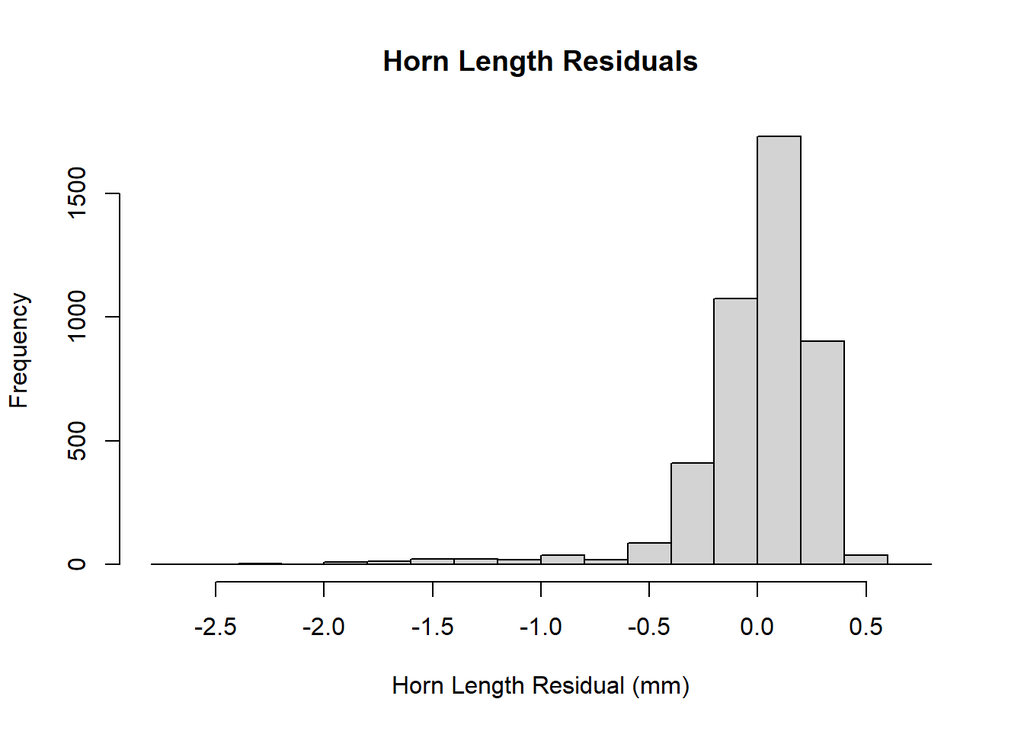

```r
m4.1 <- lm(log(hornL) ~ yr * age, data = dat)
hist(m4.1$res, breaks = 20,
     main = "Horn Length Residuals", xlab = "Horn Length Residual (mm)")
```

```r
summary(m4.1)
```

```
##
## Call:
## lm(formula = log(hornL) ~ yr * age, data = dat)
##
## Residuals:
##      Min       1Q   Median       3Q      Max
## -2.70807 -0.09104  0.05629  0.18165  0.60057
##
## Coefficients:
##               Estimate Std. Error t value Pr(>|t|)
## (Intercept) 20.3659301  1.6600578  12.268  < 2e-16 ***
## yr          -0.0077123  0.0008296  -9.296  < 2e-16 ***
## age         -1.9064468  0.3364196  -5.667 1.55e-08 ***
## yr:age       0.0009793  0.0001680   5.830 5.96e-09 ***
## ---
## Signif. codes:  0 '***' 0.001 '**' 0.01 '*' 0.05 '.' 0.1 ' ' 1
##
## Residual standard error: 0.3114 on 4390 degrees of freedom
## Multiple R-squared:  0.2425, Adjusted R-squared:  0.242
## F-statistic: 468.5 on 3 and 4390 DF,  p-value: < 2.2e-16
```

## Age Grouping (Explaining Variance)

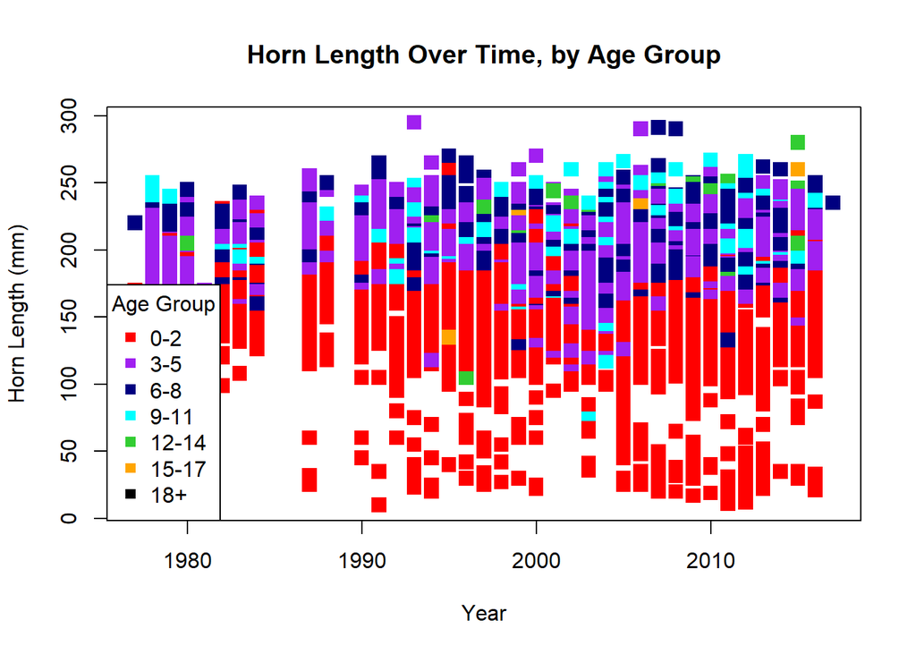

```r
plot(dat$yr, dat$hornL, pch = 15, cex = 1.5,
     col = c("red","purple","navy","cyan","limegreen","orange","black")[1 + dat$agegroup],
     main = "Horn Length Over Time, by Age Group",
     xlab = "Year", ylab = "Horn Length (mm)")
legend("bottomleft", c("0-2", "3-5", "6-8", "9-11", "12-14", "15-17", "18+"),
       pch = 15, col = c("red","purple","navy","cyan","limegreen","orange","black"),
       title = "Age Group")
```

```r
m <- glmmTMB(hornL ~ yr + (1|agegroup), data = dat)
summary(m)
```

```
##  Family: gaussian  ( identity )
## Formula:          hornL ~ yr + (1 | agegroup)
## Data: dat
##
##      AIC      BIC   logLik deviance df.resid
##  43393.8  43419.4 -21692.9  43385.8     4390
##
## Random effects:
##
## Conditional model:
##  Groups   Name        Variance Std.Dev.
##  agegroup (Intercept)  519     22.78
##  Residual             1129     33.60
## Number of obs: 4394, groups:  agegroup, 7
##
## Dispersion estimate for gaussian family (sigma^2): 1.13e+03
##
## Conditional model:
##              Estimate Std. Error z value Pr(>|z|)
## (Intercept) 935.10934  110.96716   8.427  < 2e-16 ***
## yr           -0.36861    0.05524  -6.673  2.5e-11 ***
## ---
## Signif. codes:  0 '***' 0.001 '**' 0.01 '*' 0.05 '.' 0.1 ' ' 1
```

It appears there is a slight decline in horn length over the time, -0.37mm/year, and age grouping accounts for 31% of the variation in the data.

# Other Horn Length

## Horn Length

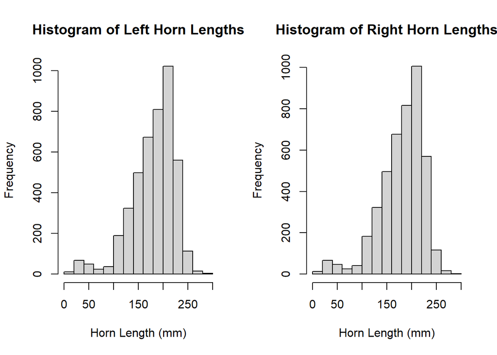

```r
par(mfrow = c(1, 2))
hist(dat$hornL, main = "Histogram of Left Horn Lengths", xlab = "Horn Length (mm)")
hist(dat$hornR, main = "Histogram of Right Horn Lengths", xlab = "Horn Length (mm)")
```

```r
par(mfrow = c(1, 1))
print(c(mean(dat$hornL), sd(dat$hornL)))
```

```
## [1] 181.7376  44.0171
```

```r
print(c(mean(dat$hornR), sd(dat$hornR)))
```

```
## [1] 181.88325  44.01339
```

## Horn Length Across Sexes

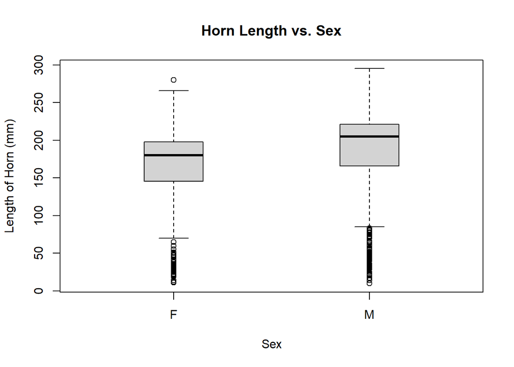

```r
# A simple boxplot of horn length for each sex
boxplot(hornL ~ as.factor(sex), data = dat, boxwex = 0.3,
        main = "Horn Length vs. Sex", xlab = "Sex", ylab = "Length of Horn (mm)")
```

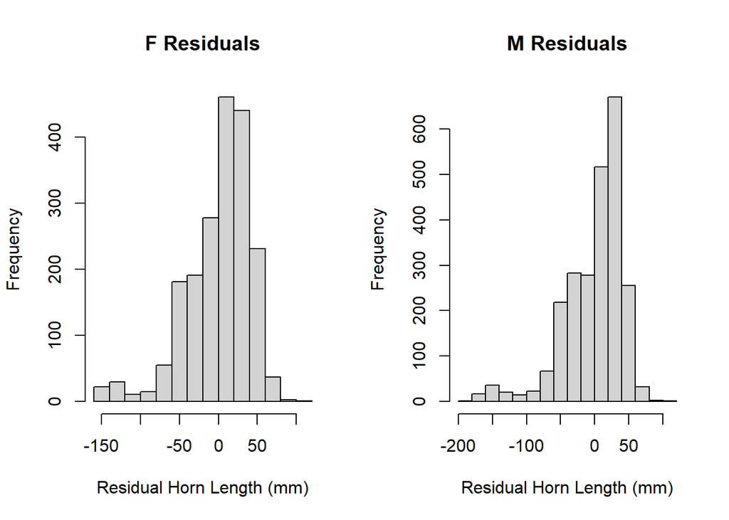

```r
length_by_sex <- lm(hornL ~ as.factor(sex), data = dat)
# The following *would* be the anova analysis, if the data were normally distributed
# summary(length_by_sex)
# anova(length_by_sex)

# The residuals are also split according to sex, to be analyzed individually
group_residuals <- split(residuals(length_by_sex), dat$sex)

# The following histograms shows the residuals are non-normal
par(mfrow = c(1, 2))
hist(unlist(group_residuals[1], use.names = F),
     main = "F Residuals",
     xlab = "Residual Horn Length (mm)")
hist(unlist(group_residuals[2], use.names = F),
     main = "M Residuals",
     xlab = "Residual Horn Length (mm)")
```

```r
par(mfrow = c(1, 1))

# The results of the following Shapiro-Wilkes test confirm they are non-normal
lapply(group_residuals, shapiro.test)
```

```
## $F
##
##  Shapiro-Wilk normality test
##
## data:  X[[i]]
## W = 0.92457, p-value < 2.2e-16
##
##
## $M
##
##  Shapiro-Wilk normality test
##
## data:  X[[i]]
## W = 0.89269, p-value < 2.2e-16
```

```r
# Then a Kruskal test is used instead, as it is appropriate for non-normal residuals
kruskal.test(hornL ~ as.factor(sex), data = dat)
```

```
##
##  Kruskal-Wallis rank sum test
##
## data:  hornL by as.factor(sex)
## Kruskal-Wallis chi-squared = 443.71, df = 1, p-value < 2.2e-16
```

## Horn Length vs. Population Density

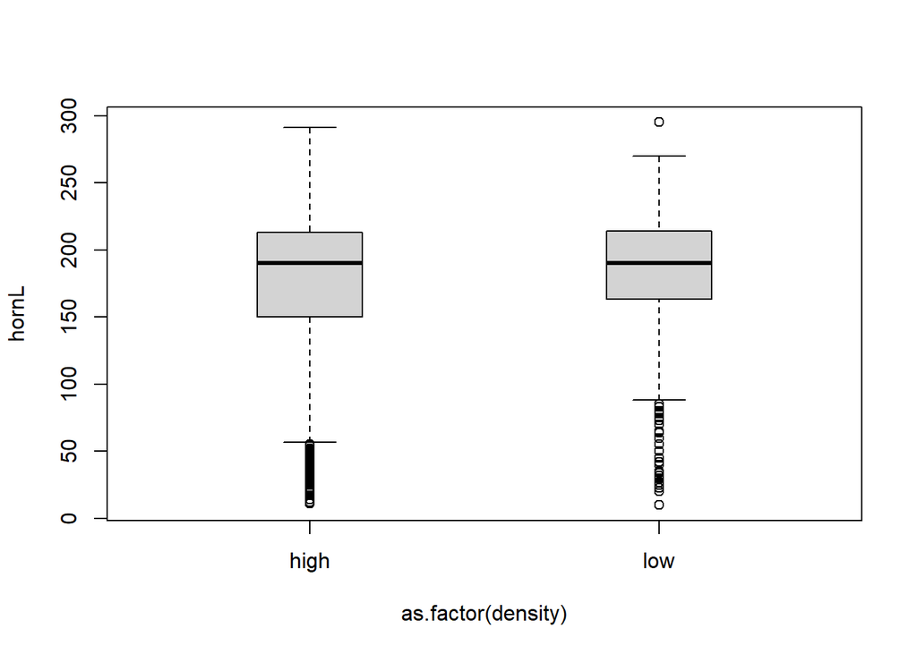

```r
# This is the same analysis as what was done for the sexes
boxplot(hornL ~ as.factor(density), data = dat, boxwex = 0.3)
```

```r
density_anova <- lm(hornL ~ as.factor(density), data = dat)
summary(density_anova)
```

```
##
## Call:
## lm(formula = hornL ~ as.factor(density), data = dat)
##
## Residuals:
##      Min       1Q   Median       3Q      Max
## -175.697  -23.992    8.008   32.008  113.008
##
## Coefficients:
##                       Estimate Std. Error t value Pr(>|t|)
## (Intercept)           177.9925     0.9229  192.87  < 2e-16 ***
## as.factor(density)low   7.7042     1.3236    5.82 6.29e-09 ***
## ---
## Signif. codes:  0 '***' 0.001 '**' 0.01 '*' 0.05 '.' 0.1 ' ' 1
##
## Residual standard error: 43.85 on 4392 degrees of freedom
## Multiple R-squared:  0.007654,   Adjusted R-squared:  0.007428
## F-statistic: 33.88 on 1 and 4392 DF,  p-value: 6.287e-09
```

```r
anova(density_anova)
```

```
## Analysis of Variance Table
##
## Response: hornL
##                      Df  Sum Sq Mean Sq F value    Pr(>F)
## as.factor(density)    1   65150   65150  33.877 6.287e-09 ***
## Residuals          4392 8446310    1923
## ---
## Signif. codes:  0 '***' 0.001 '**' 0.01 '*' 0.05 '.' 0.1 ' ' 1
```

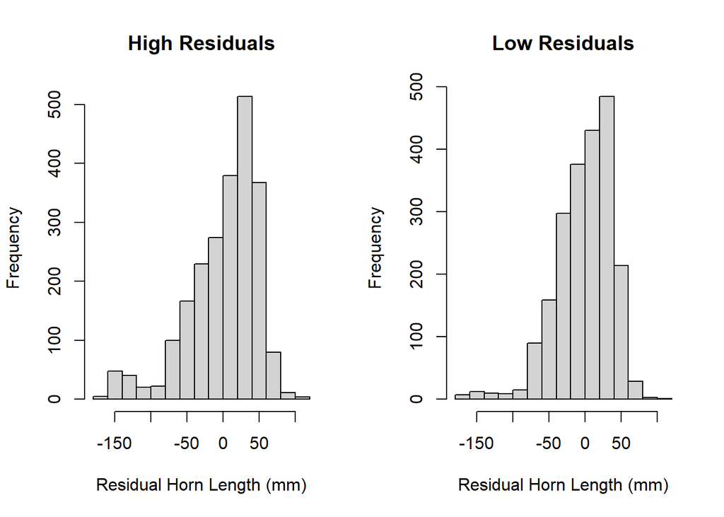

```r
group_residuals <- split(residuals(density_anova), dat$density)
par(mfrow = c(1, 2))
hist(unlist(group_residuals[1], use.names = F),
     main = "High Residuals",
     xlab = "Residual Horn Length (mm)")
hist(unlist(group_residuals[2], use.names = F),
     main = "Low Residuals",
     xlab = "Residual Horn Length (mm)")
```

```r
par(mfrow = c(1, 1))
print("-----------------")
```

```
## [1] "-----------------"
```

```r
kruskal.test(hornL ~ as.factor(density), data = dat)
```

```
##
##  Kruskal-Wallis rank sum test
##
## data:  hornL by as.factor(density)
## Kruskal-Wallis chi-squared = 10.952, df = 1, p-value = 0.0009351
```

The histograms for population density show the same results: the residuals are not normally distributed within groups. Thus the analysis is also untrustworthy here. Here, the Kruskal-Wallis test gives a chi-squared of 10.952 with a p-value of 0.0009351. The epsilon-squared value here is (10.952 - 2 + 1)/(4394 - 2) = 0.00227. Thus we can say approximately 0.2% of the horn length variation can be attributed to population density.